# NUS ST5207 — Nonparametric Regression

## Theory, Algorithms, Experiments, and a Real-Data Case Study

This notebook is a tutorial-style companion to the main ideas typically associated with **nonparametric regression**:

1. Parametric vs nonparametric modelling
2. Histograms and density estimation
3. Kernel Density Estimation (KDE)
4. Kernel regression / Nadaraya–Watson estimator
5. Local polynomial regression
6. Bandwidth and smoothing-parameter selection
7. Regression splines
8. Smoothing splines
9. Additive models / GAM-like models
10. Semiparametric regression
11. Bias–variance trade-off
12. Curse of dimensionality
13. Consistency and convergence-rate intuition
14. Real-data case study

The notebook deliberately combines:

- mathematical intuition,
- from-scratch implementations,
- established Python libraries,
- visualization,
- hyperparameter experimentation,
- cross-validation,
- model comparison.

> **Case study dataset:** Auto MPG data, downloaded directly from the UCI Machine Learning Repository when this notebook runs.

The core prediction problem is:

[ Y = m(X) + \varepsilon ]

where the unknown regression function (m(\cdot)) is estimated without forcing it to have a fixed global form such as a straight line.

```python
# Core imports
import warnings
warnings.filterwarnings("ignore")

import numpy as np
import pandas as pd
import matplotlib.pyplot as plt

from scipy import stats
from scipy.interpolate import UnivariateSpline

from sklearn.base import BaseEstimator, RegressorMixin
from sklearn.preprocessing import SplineTransformer, StandardScaler
from sklearn.pipeline import Pipeline
from sklearn.linear_model import LinearRegression, Ridge
from sklearn.model_selection import (
    train_test_split,
    KFold,
    GridSearchCV,
    cross_val_score,
)
from sklearn.metrics import mean_squared_error, mean_absolute_error, r2_score
from sklearn.kernel_ridge import KernelRidge

np.random.seed(42)

print("Environment ready.")
```

```
Environment ready.
```

# 1. Parametric vs Nonparametric Regression

A **parametric model** assumes that the relationship belongs to a predefined finite-dimensional family.

For example:

[ Y = \beta_0 + \beta_1 X + \varepsilon ]

or

[ Y = \beta_0 + \beta_1 X + \beta_2 X^2 + \varepsilon. ]

The unknown object is a finite parameter vector:

[ \theta = (\beta_0,\beta_1,\ldots). ]

A **nonparametric model** instead estimates an unknown function:

[ Y = m(X)+\varepsilon. ]

The function (m(x)) may be nonlinear and its effective complexity can increase with the amount of data.

Examples include:

- kernel regression,
- local polynomial regression,
- smoothing splines,
- regression splines,
- additive models.

The flexibility is useful, but it creates an important trade-off:

[ \text{More flexibility} \Rightarrow \text{lower bias but potentially higher variance}. ]

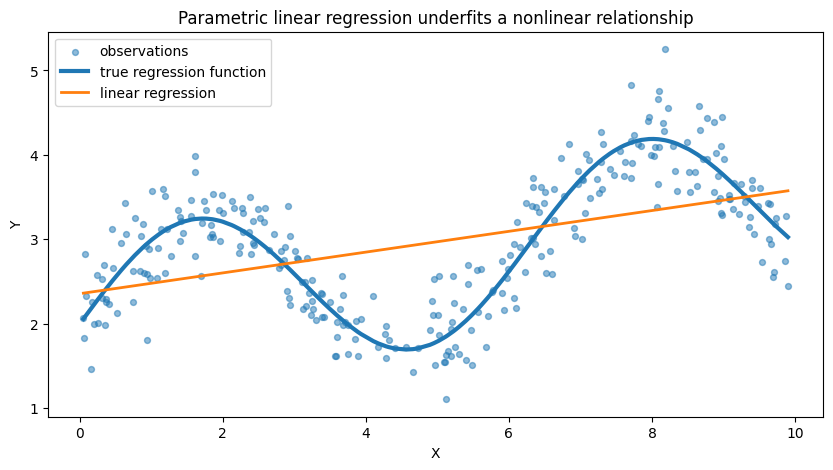

```python
# Synthetic nonlinear regression problem

n = 300
X = np.sort(np.random.uniform(0, 10, size=n))
true_f = 2 + np.sin(X) + 0.15 * X
y = true_f + np.random.normal(0, 0.35, size=n)

X2 = X.reshape(-1, 1)

linear = LinearRegression().fit(X2, y)
pred_linear = linear.predict(X2)

plt.figure(figsize=(10, 5))
plt.scatter(X, y, s=18, alpha=0.5, label="observations")
plt.plot(X, true_f, linewidth=3, label="true regression function")
plt.plot(X, pred_linear, linewidth=2, label="linear regression")
plt.xlabel("X")
plt.ylabel("Y")
plt.title("Parametric linear regression underfits a nonlinear relationship")
plt.legend()
plt.show()
```

# 2. Histograms as Nonparametric Density Estimators

Before regression, it is useful to understand the simpler problem of **density estimation**.

Given observations

[ X_1,\ldots,X_n, ]

we wish to estimate their unknown density (f(x)).

A histogram partitions the domain into bins of width (h). For a bin (B_j),

# [ \hat f(x)

\frac{#{X_i\in B_j}}{nh}, \qquad x\in B_j. ]

The bin width acts as a **smoothing parameter**.

- too small (h): highly variable estimate,
- too large (h): excessive smoothing.

This same bias–variance principle reappears in KDE and regression smoothing.

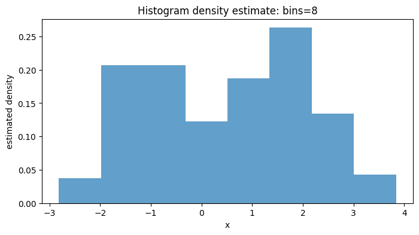

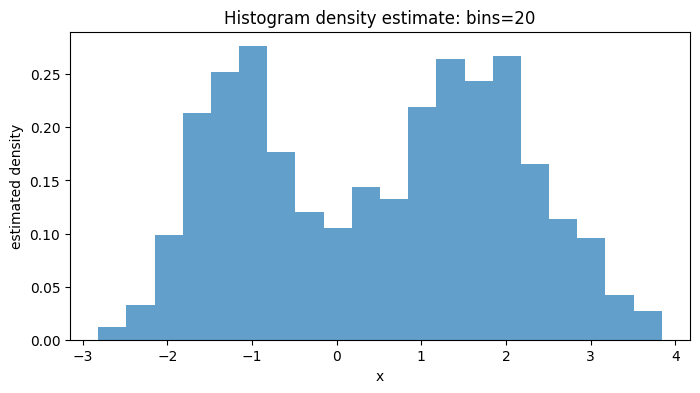

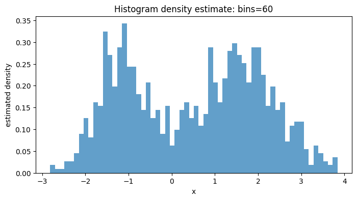

```python
sample = np.concatenate([
    np.random.normal(-1.2, 0.6, 400),
    np.random.normal(1.5, 0.9, 600),
])

for bins in [8, 20, 60]:
    plt.figure(figsize=(8, 4))
    plt.hist(sample, bins=bins, density=True, alpha=0.7)
    plt.title(f"Histogram density estimate: bins={bins}")
    plt.xlabel("x")
    plt.ylabel("estimated density")
    plt.show()
```

# 3. Kernel Density Estimation

A histogram estimate is discontinuous and strongly dependent on arbitrary bin boundaries.

Kernel Density Estimation replaces bins with smooth local contributions:

# [ \hat f_h(x)

\frac{1}{nh} \sum_{i=1}^n K\left(\frac{x-X_i}{h}\right). ]

Here:

- (K) is the kernel,
- (h>0) is the bandwidth.

A Gaussian kernel is

# [ K(u)

\frac{1}{\sqrt{2\pi}} e^{-u^2/2}. ]

The bandwidth usually matters much more than the exact kernel choice.

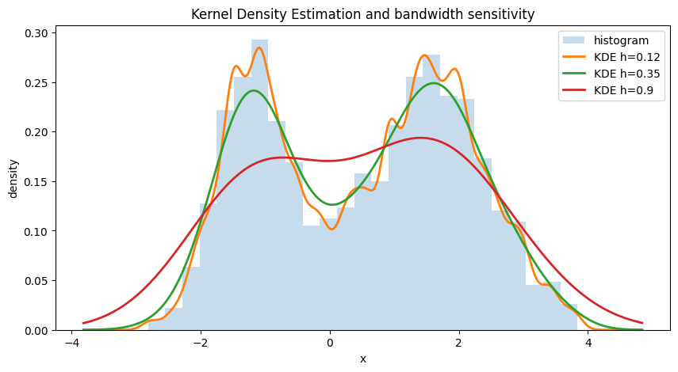

```python
def gaussian_kernel(u):
    return np.exp(-0.5 * u**2) / np.sqrt(2 * np.pi)

def kde_1d(x_eval, x_train, bandwidth):
    x_eval = np.asarray(x_eval)[:, None]
    x_train = np.asarray(x_train)[None, :]
    u = (x_eval - x_train) / bandwidth
    return gaussian_kernel(u).mean(axis=1) / bandwidth

grid = np.linspace(sample.min() - 1, sample.max() + 1, 500)

plt.figure(figsize=(10, 5))
plt.hist(sample, bins=25, density=True, alpha=0.25, label="histogram")

for h in [0.12, 0.35, 0.9]:
    plt.plot(grid, kde_1d(grid, sample, h), linewidth=2, label=f"KDE h={h}")

plt.title("Kernel Density Estimation and bandwidth sensitivity")
plt.xlabel("x")
plt.ylabel("density")
plt.legend()
plt.show()
```

## 3.1 KDE Bias–Variance Intuition

For many smooth densities, the leading terms behave approximately like

[ \mathrm{Bias}[\hat f_h(x)] = O(h^2), ]

and

# [ \mathrm{Var}[\hat f_h(x)]

O\left(\frac{1}{nh}\right). ]

Therefore,

[ \mathrm{MSE} \approx C_1 h^4 + \frac{C_2}{nh}. ]

Balancing the two terms yields the famous one-dimensional order

# [ h_{\mathrm{opt}}

O(n^{-1/5}). ]

This is one of the central rate calculations in nonparametric statistics.

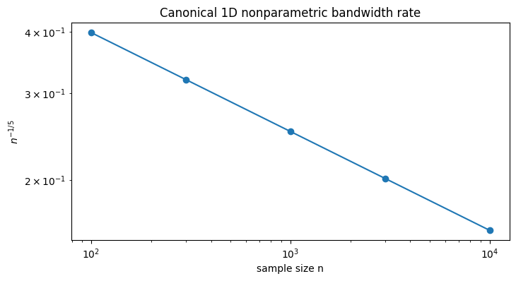

```python
n_values = np.array([100, 300, 1000, 3000, 10000])
rate = n_values ** (-1/5)

plt.figure(figsize=(8, 4))
plt.plot(n_values, rate, marker="o")
plt.xscale("log")
plt.yscale("log")
plt.xlabel("sample size n")
plt.ylabel(r"$n^{-1/5}$")
plt.title("Canonical 1D nonparametric bandwidth rate")
plt.show()
```

# 4. Kernel Regression — Nadaraya–Watson Estimator

For regression,

[ Y_i = m(X_i)+\varepsilon_i, ]

the Nadaraya–Watson estimator is

# [ \hat m_h(x)

\frac{ \sum_{i=1}^n K\left(\frac{x-X_i}{h}\right)Y_i }{ \sum_{i=1}^n K\left(\frac{x-X_i}{h}\right) }. ]

Interpretation:

1. calculate the distance from (x) to every training observation,
2. convert distances into kernel weights,
3. compute a locally weighted average of responses.

The bandwidth (h) controls locality.

```python
class NadarayaWatsonRegressor(BaseEstimator, RegressorMixin):
    def __init__(self, bandwidth=1.0):
        self.bandwidth = bandwidth

    def fit(self, X, y):
        self.X_ = np.asarray(X).reshape(-1)
        self.y_ = np.asarray(y)
        return self

    def predict(self, X):
        X = np.asarray(X).reshape(-1)
        preds = []

        for x in X:
            u = (x - self.X_) / self.bandwidth
            w = gaussian_kernel(u)

            if w.sum() < 1e-12:
                preds.append(self.y_.mean())
            else:
                preds.append(np.dot(w, self.y_) / w.sum())

        return np.asarray(preds)
```

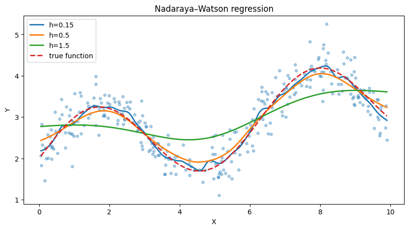

```python
grid_reg = np.linspace(X.min(), X.max(), 400)

plt.figure(figsize=(10, 5))
plt.scatter(X, y, s=15, alpha=0.35)

for h in [0.15, 0.5, 1.5]:
    model = NadarayaWatsonRegressor(bandwidth=h).fit(X, y)
    pred = model.predict(grid_reg)
    plt.plot(grid_reg, pred, linewidth=2, label=f"h={h}")

plt.plot(X, true_f, linestyle="--", linewidth=2, label="true function")
plt.title("Nadaraya–Watson regression")
plt.xlabel("X")
plt.ylabel("Y")
plt.legend()
plt.show()
```

## Interpretation

Typical pattern:

- (h=0.15): follows small fluctuations and noise,
- (h=0.5): captures the dominant nonlinear structure,
- (h=1.5): smooth but potentially biased.

This is nonparametric model complexity control.

Unlike a polynomial degree, complexity is not described by a fixed number of coefficients. Instead it is primarily controlled through the **smoothing parameter**.

# 5. Local Polynomial Regression

The Nadaraya–Watson estimator is also called a **local constant estimator**.

Near a query point (x_0), it effectively assumes:

[ m(x)\approx \beta_0. ]

Local linear regression instead approximates

[ m(x) \approx \beta_0+\beta_1(x-x_0). ]

For each query point (x_0), solve

[ \min_{\beta_0,\beta_1} \sum_{i=1}^n K\left( \frac{X_i-x_0}{h} \right) \left[ Y_i-\beta_0-\beta_1(X_i-x_0) \right]^2. ]

Then

[ \hat m(x_0)=\hat\beta_0. ]

A major advantage is reduced boundary bias.

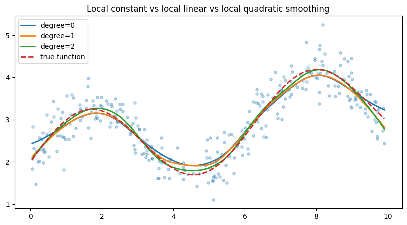

```python
def local_polynomial_predict(x_train, y_train, x_eval, bandwidth, degree=1):
    x_train = np.asarray(x_train)
    y_train = np.asarray(y_train)
    x_eval = np.asarray(x_eval)

    preds = []

    for x0 in x_eval:
        dx = x_train - x0
        w = gaussian_kernel(dx / bandwidth)

        # Design matrix:
        # [1, dx, dx^2, ..., dx^degree]
        A = np.column_stack([dx ** j for j in range(degree + 1)])

        W = np.sqrt(w)[:, None]
        Aw = A * W
        yw = y_train * W[:, 0]

        beta, *_ = np.linalg.lstsq(Aw, yw, rcond=None)
        preds.append(beta[0])

    return np.asarray(preds)

plt.figure(figsize=(10, 5))
plt.scatter(X, y, s=15, alpha=0.3)

for degree in [0, 1, 2]:
    pred = local_polynomial_predict(
        X, y, grid_reg,
        bandwidth=0.5,
        degree=degree
    )
    plt.plot(grid_reg, pred, linewidth=2, label=f"degree={degree}")

plt.plot(X, true_f, linestyle="--", linewidth=2, label="true function")
plt.title("Local constant vs local linear vs local quadratic smoothing")
plt.legend()
plt.show()
```

# 6. Bandwidth Selection by Cross-Validation

The bandwidth should normally be selected from the data.

A common objective is leave-one-out cross-validation:

# [ CV(h)

\frac{1}{n} \sum_{i=1}^n \left[ Y_i-\hat m_{-i,h}(X_i) \right]^2. ]

Here (\hat m_{-i,h}) is fitted without observation (i).

The bandwidth minimizing this estimate is selected.

```
Best bandwidth: 0.24736842105263157
```

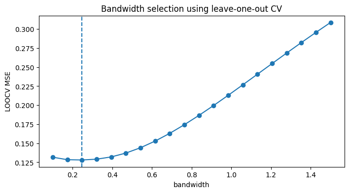

```python
def loo_cv_nw(x, y, bandwidth):
    x = np.asarray(x)
    y = np.asarray(y)
    errors = []

    for i in range(len(x)):
        mask = np.arange(len(x)) != i

        model = NadarayaWatsonRegressor(
            bandwidth=bandwidth
        ).fit(x[mask], y[mask])

        pred = model.predict([x[i]])[0]
        errors.append((y[i] - pred) ** 2)

    return np.mean(errors)

candidate_h = np.linspace(0.1, 1.5, 20)
cv_scores = [loo_cv_nw(X, y, h) for h in candidate_h]

best_h = candidate_h[np.argmin(cv_scores)]
print("Best bandwidth:", best_h)

plt.figure(figsize=(8, 4))
plt.plot(candidate_h, cv_scores, marker="o")
plt.axvline(best_h, linestyle="--")
plt.xlabel("bandwidth")
plt.ylabel("LOOCV MSE")
plt.title("Bandwidth selection using leave-one-out CV")
plt.show()
```

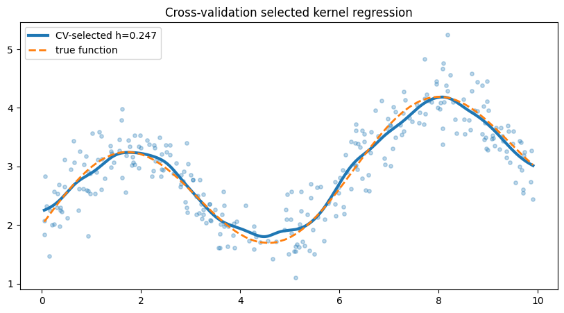

```python
best_nw = NadarayaWatsonRegressor(best_h).fit(X, y)
best_pred = best_nw.predict(grid_reg)

plt.figure(figsize=(10, 5))
plt.scatter(X, y, s=15, alpha=0.3)
plt.plot(grid_reg, best_pred, linewidth=3, label=f"CV-selected h={best_h:.3f}")
plt.plot(X, true_f, linestyle="--", linewidth=2, label="true function")
plt.title("Cross-validation selected kernel regression")
plt.legend()
plt.show()
```

# 7. Boundary Bias

Kernel regression behaves differently near the boundaries of the predictor domain.

At an interior point, observations are usually available on both sides.

Near an edge, kernel support becomes asymmetric, which can distort a local constant estimate.

Local linear regression partially corrects this by fitting a local slope.

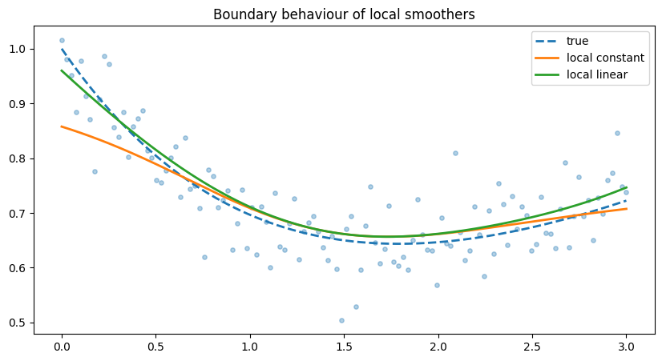

```python
# Boundary-focused synthetic dataset
xb = np.linspace(0, 3, 120)
yb_true = np.exp(-0.7 * xb) + 0.2 * xb
yb = yb_true + np.random.normal(0, 0.05, len(xb))

grid_b = np.linspace(0, 3, 300)

nw_b = NadarayaWatsonRegressor(0.45).fit(xb, yb).predict(grid_b)
ll_b = local_polynomial_predict(xb, yb, grid_b, bandwidth=0.45, degree=1)

plt.figure(figsize=(10, 5))
plt.scatter(xb, yb, s=15, alpha=0.35)
plt.plot(grid_b, np.exp(-0.7 * grid_b) + 0.2 * grid_b, linestyle="--", linewidth=2, label="true")
plt.plot(grid_b, nw_b, linewidth=2, label="local constant")
plt.plot(grid_b, ll_b, linewidth=2, label="local linear")
plt.title("Boundary behaviour of local smoothers")
plt.legend()
plt.show()
```

# 8. Regression Splines

Splines approximate an unknown smooth function using **piecewise polynomials** joined at points called **knots**.

A spline model can be represented as

# [ m(x)

\sum_{j=1}^{K} \beta_j B_j(x), ]

where (B_j(x)) are basis functions.

Compared with fitting one high-degree global polynomial, splines are:

- more numerically stable,
- more local,
- much less prone to extreme oscillation.

Common spline families include:

- truncated power bases,
- B-splines,
- natural cubic splines.

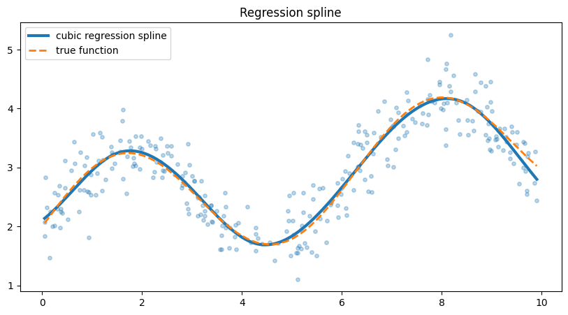

```python
spline_model = Pipeline([
    ("spline", SplineTransformer(
        degree=3,
        n_knots=8,
        include_bias=False
    )),
    ("regressor", LinearRegression())
])

spline_model.fit(X2, y)
pred_spline = spline_model.predict(grid_reg.reshape(-1, 1))

plt.figure(figsize=(10, 5))
plt.scatter(X, y, s=15, alpha=0.3)
plt.plot(grid_reg, pred_spline, linewidth=3, label="cubic regression spline")
plt.plot(X, true_f, linestyle="--", linewidth=2, label="true function")
plt.title("Regression spline")
plt.legend()
plt.show()
```

## 8.1 Knot Count as a Complexity Parameter

More knots create a richer basis.

This resembles bandwidth selection:

- many knots → low bias / high variance,
- few knots → high bias / low variance.

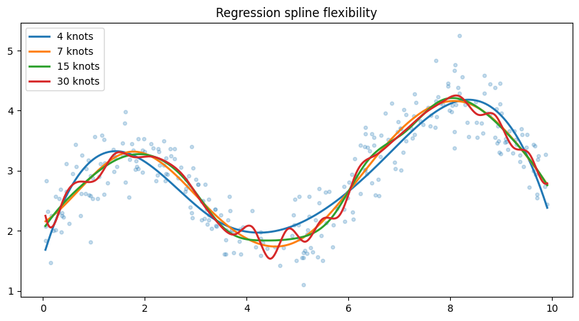

```python
plt.figure(figsize=(10, 5))
plt.scatter(X, y, s=12, alpha=0.25)

for n_knots in [4, 7, 15, 30]:
    model = Pipeline([
        ("spline", SplineTransformer(
            degree=3,
            n_knots=n_knots,
            include_bias=False
        )),
        ("regressor", LinearRegression())
    ])

    model.fit(X2, y)
    pred = model.predict(grid_reg.reshape(-1, 1))
    plt.plot(grid_reg, pred, linewidth=2, label=f"{n_knots} knots")

plt.title("Regression spline flexibility")
plt.legend()
plt.show()
```

# 9. Penalized / Smoothing-Spline Idea

Regression splines control complexity partly through the number and position of knots.

Smoothing splines instead optimize a penalized criterion:

[ \sum_{i=1}^n (Y_i-f(X_i))^2 + \lambda \int [f''(x)]^2dx. ]

The first term rewards fit.

The second penalizes curvature.

Hence:

- small (\lambda): flexible / wiggly,
- large (\lambda): smooth,
- (\lambda\to\infty): approaches a straight line.

`scipy.interpolate.UnivariateSpline` uses a related smoothing formulation controlled by `s`.

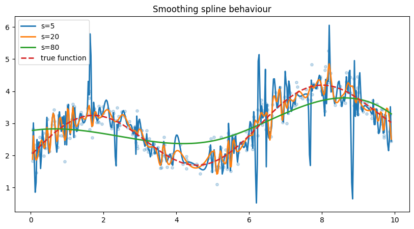

```python
plt.figure(figsize=(10, 5))
plt.scatter(X, y, s=15, alpha=0.25)

for s in [5, 20, 80]:
    us = UnivariateSpline(X, y, s=s)
    plt.plot(grid_reg, us(grid_reg), linewidth=2, label=f"s={s}")

plt.plot(X, true_f, linestyle="--", linewidth=2, label="true function")
plt.title("Smoothing spline behaviour")
plt.legend()
plt.show()
```

# 10. Penalized Spline Basis with Ridge Regression

Another practical construction is:

1. create many spline basis functions,
2. penalize coefficients with Ridge regression.

# [ \hat\beta

\arg\min_\beta \left{ |y-B\beta|_2^2 + \alpha |\beta|_2^2 \right}. ]

This connects nonparametric smoothing to regularization.

```
Best alpha: 0.08858667904100823
```

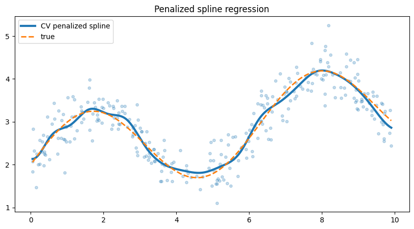

```python
penalized_spline = Pipeline([
    ("spline", SplineTransformer(
        degree=3,
        n_knots=20,
        include_bias=False
    )),
    ("ridge", Ridge(alpha=1.0))
])

param_grid = {
    "ridge__alpha": np.logspace(-4, 3, 20)
}

grid_search = GridSearchCV(
    penalized_spline,
    param_grid,
    cv=5,
    scoring="neg_mean_squared_error",
    n_jobs=-1
)

grid_search.fit(X2, y)

print("Best alpha:", grid_search.best_params_["ridge__alpha"])

pred_pen = grid_search.predict(grid_reg.reshape(-1, 1))

plt.figure(figsize=(10, 5))
plt.scatter(X, y, s=15, alpha=0.25)
plt.plot(grid_reg, pred_pen, linewidth=3, label="CV penalized spline")
plt.plot(X, true_f, linestyle="--", linewidth=2, label="true")
plt.title("Penalized spline regression")
plt.legend()
plt.show()
```

# 11. Additive Models

For several predictors, fully multivariate nonparametric smoothing quickly becomes difficult.

An additive model assumes

# [ Y

\beta_0 + f_1(X_1) + f_2(X_2) + \cdots + f_p(X_p) + \varepsilon. ]

Each individual effect can remain nonlinear, while the decomposition avoids estimating an unrestricted (p)-dimensional surface.

This is the basic structure behind **Generalized Additive Models (GAMs)**.

```python
# Synthetic additive data

n = 800

x1 = np.random.uniform(-3, 3, n)
x2 = np.random.uniform(0, 5, n)

y_add = (
    np.sin(x1)
    + 0.35 * (x2 - 2.5) ** 2
    + np.random.normal(0, 0.3, n)
)

X_add = np.column_stack([x1, x2])

# Build spline bases separately, concatenate, then regress.
s1 = SplineTransformer(n_knots=8, degree=3, include_bias=False)
s2 = SplineTransformer(n_knots=8, degree=3, include_bias=False)

B1 = s1.fit_transform(x1.reshape(-1, 1))
B2 = s2.fit_transform(x2.reshape(-1, 1))

B = np.column_stack([B1, B2])

add_model = Ridge(alpha=1.0).fit(B, y_add)
pred_add = add_model.predict(B)

print("Training R2:", r2_score(y_add, pred_add))
print("Training RMSE:", mean_squared_error(y_add, pred_add) ** 0.5)
```

```
Training R2: 0.9083295378829317
Training RMSE: 0.3108576881816311
```

## Recovering Partial Effects

To visualize (f_1(x_1)), vary (x_1) while holding the (x_2)-basis contribution at a reference value.

Similarly for (f_2(x_2)).

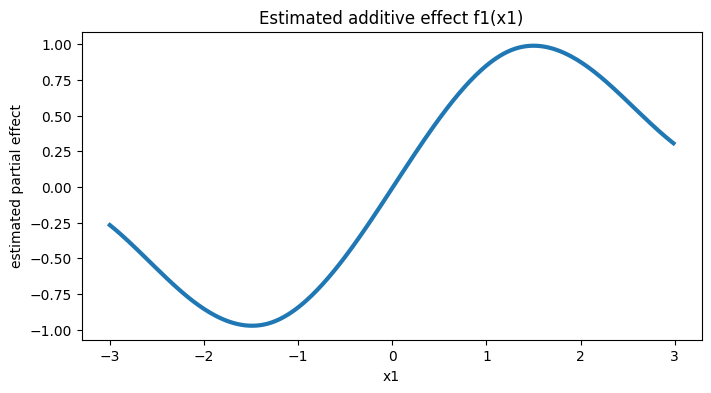

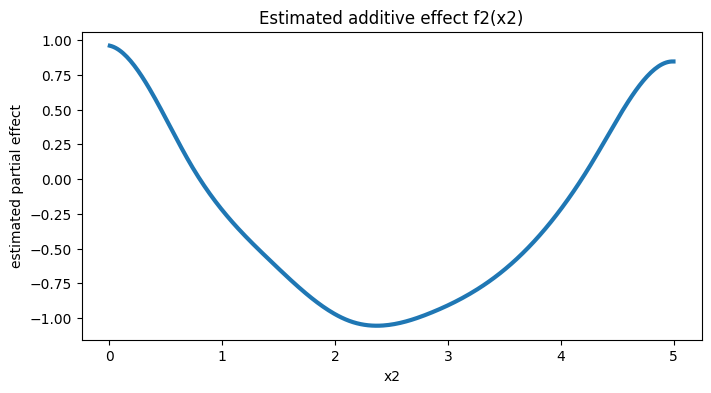

```python
grid1 = np.linspace(x1.min(), x1.max(), 300)
grid2 = np.linspace(x2.min(), x2.max(), 300)

coef1 = add_model.coef_[:B1.shape[1]]
coef2 = add_model.coef_[B1.shape[1]:]

effect1 = s1.transform(grid1.reshape(-1,1)) @ coef1
effect2 = s2.transform(grid2.reshape(-1,1)) @ coef2

plt.figure(figsize=(8, 4))
plt.plot(grid1, effect1, linewidth=3)
plt.xlabel("x1")
plt.ylabel("estimated partial effect")
plt.title("Estimated additive effect f1(x1)")
plt.show()

plt.figure(figsize=(8, 4))
plt.plot(grid2, effect2, linewidth=3)
plt.xlabel("x2")
plt.ylabel("estimated partial effect")
plt.title("Estimated additive effect f2(x2)")
plt.show()
```

# 12. Semiparametric Regression

A semiparametric model mixes parametric and nonparametric components.

A canonical example is the partially linear model:

# [ Y

Z^\top\beta + g(X) + \varepsilon. ]

Here:

- (Z^\top\beta) is parametric,
- (g(X)) is nonparametric.

This is useful when:

- some effects are believed to be approximately linear,
- another predictor requires flexible nonlinear modelling,
- interpretable coefficients are still desirable.

```python
# Synthetic partially linear example

n = 700

x = np.random.uniform(0, 8, n)
z = np.random.normal(size=n)

g_true = 1.5 * np.sin(x / 1.3)
beta_true = 2.2

y_semi = beta_true * z + g_true + np.random.normal(0, 0.4, n)

# Nonparametric part approximated with spline basis.
spline = SplineTransformer(n_knots=10, degree=3, include_bias=False)
Bx = spline.fit_transform(x.reshape(-1, 1))

design = np.column_stack([z, Bx])

semi_model = Ridge(alpha=0.1).fit(design, y_semi)

beta_hat = semi_model.coef_[0]

print("True linear coefficient:", beta_true)
print("Estimated linear coefficient:", beta_hat)
```

```
True linear coefficient: 2.2
Estimated linear coefficient: 2.175560968342789
```

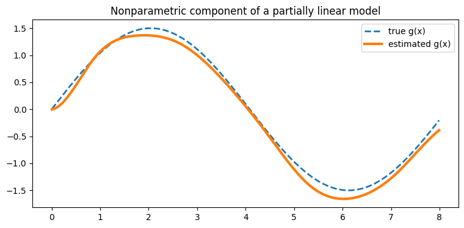

```python
grid_x = np.linspace(x.min(), x.max(), 300)

coef_g = semi_model.coef_[1:]
g_hat = spline.transform(grid_x.reshape(-1,1)) @ coef_g

plt.figure(figsize=(9, 4))
plt.plot(grid_x, 1.5*np.sin(grid_x/1.3), linestyle="--", linewidth=2, label="true g(x)")
plt.plot(grid_x, g_hat, linewidth=3, label="estimated g(x)")
plt.title("Nonparametric component of a partially linear model")
plt.legend()
plt.show()
```

# 13. Curse of Dimensionality

Nonparametric methods rely on **local observations**.

In one dimension, a small neighbourhood may still contain many samples.

In higher dimensions, volume grows rapidly.

For a (d)-dimensional hypercube with side width (r),

[ V=r^d. ]

If (r=0.1):

- (d=1): (10^{-1}),
- (d=2): (10^{-2}),
- (d=5): (10^{-5}),
- (d=10): (10^{-10}).

Thus huge datasets may be required to populate local neighbourhoods.

This motivates:

- additive assumptions,
- dimensionality reduction,
- structural constraints,
- regularization,
- semiparametric models.

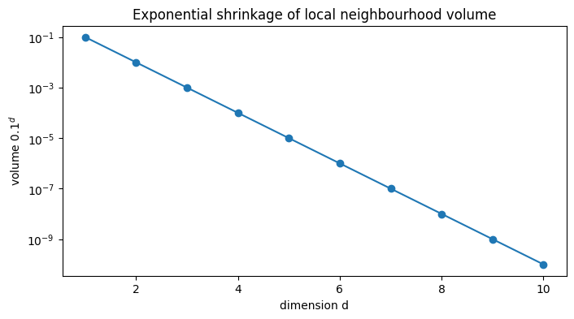

```python
dims = np.arange(1, 11)
r = 0.1
volumes = r ** dims

plt.figure(figsize=(8, 4))
plt.plot(dims, volumes, marker="o")
plt.yscale("log")
plt.xlabel("dimension d")
plt.ylabel(r"volume $0.1^d$")
plt.title("Exponential shrinkage of local neighbourhood volume")
plt.show()
```

# 14. Real-Data Case Study — Auto MPG

We now apply the ideas to a real dataset.

The **Auto MPG** dataset contains fuel-efficiency and vehicle-engine characteristics.

We will download it directly from the UCI Machine Learning Repository.

Main response variable:

[ Y=\text{mpg} ]

Key predictor for nonparametric analysis:

[ X=\text{horsepower}. ]

We will investigate whether fuel efficiency has a nonlinear relationship with horsepower.

Later we will create a partially additive model using several predictors.

```python
# Download the real dataset directly from UCI.

url = "https://archive.ics.uci.edu/ml/machine-learning-databases/auto-mpg/auto-mpg.data"

columns = [
    "mpg",
    "cylinders",
    "displacement",
    "horsepower",
    "weight",
    "acceleration",
    "model_year",
    "origin",
    "car_name",
]

auto = pd.read_csv(
    url,
    sep=r"\s+",
    names=columns,
    na_values="?"
)

print("Raw shape:", auto.shape)

auto = auto.dropna().reset_index(drop=True)

print("Clean shape:", auto.shape)
auto.head()
```

```
Raw shape: (398, 9)
Clean shape: (392, 9)
```

|  | mpg | cylinders | displacement | horsepower | weight | acceleration | model_year | origin | car_name |
| --- | --- | --- | --- | --- | --- | --- | --- | --- | --- |
| 0 | 18.0 | 8 | 307.0 | 130.0 | 3504.0 | 12.0 | 70 | 1 | chevrolet chevelle malibu |
| 1 | 15.0 | 8 | 350.0 | 165.0 | 3693.0 | 11.5 | 70 | 1 | buick skylark 320 |
| 2 | 18.0 | 8 | 318.0 | 150.0 | 3436.0 | 11.0 | 70 | 1 | plymouth satellite |
| 3 | 16.0 | 8 | 304.0 | 150.0 | 3433.0 | 12.0 | 70 | 1 | amc rebel sst |
| 4 | 17.0 | 8 | 302.0 | 140.0 | 3449.0 | 10.5 | 70 | 1 | ford torino |

```python
auto.describe()
```

|  | mpg | cylinders | displacement | horsepower | weight | acceleration | model_year | origin |
| --- | --- | --- | --- | --- | --- | --- | --- | --- |
| count | 392.000000 | 392.000000 | 392.000000 | 392.000000 | 392.000000 | 392.000000 | 392.000000 | 392.000000 |
| mean | 23.445918 | 5.471939 | 194.411990 | 104.469388 | 2977.584184 | 15.541327 | 75.979592 | 1.576531 |
| std | 7.805007 | 1.705783 | 104.644004 | 38.491160 | 849.402560 | 2.758864 | 3.683737 | 0.805518 |
| min | 9.000000 | 3.000000 | 68.000000 | 46.000000 | 1613.000000 | 8.000000 | 70.000000 | 1.000000 |
| 25% | 17.000000 | 4.000000 | 105.000000 | 75.000000 | 2225.250000 | 13.775000 | 73.000000 | 1.000000 |
| 50% | 22.750000 | 4.000000 | 151.000000 | 93.500000 | 2803.500000 | 15.500000 | 76.000000 | 1.000000 |
| 75% | 29.000000 | 8.000000 | 275.750000 | 126.000000 | 3614.750000 | 17.025000 | 79.000000 | 2.000000 |
| max | 46.600000 | 8.000000 | 455.000000 | 230.000000 | 5140.000000 | 24.800000 | 82.000000 | 3.000000 |

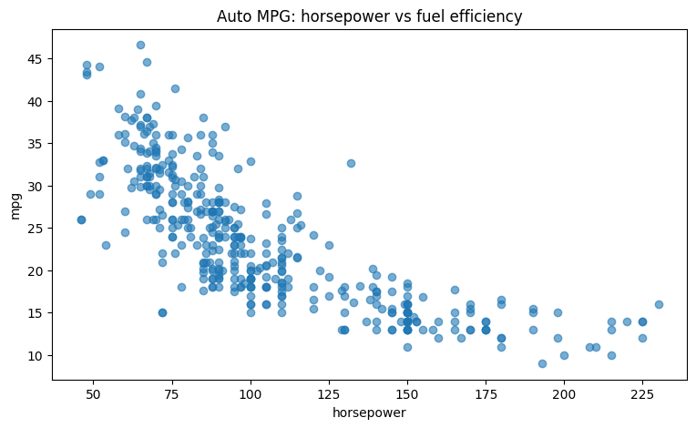

```python
plt.figure(figsize=(9, 5))
plt.scatter(auto["horsepower"], auto["mpg"], alpha=0.6)
plt.xlabel("horsepower")
plt.ylabel("mpg")
plt.title("Auto MPG: horsepower vs fuel efficiency")
plt.show()
```

## 14.1 First Baseline — Linear Regression

A global linear model assumes

# [ E[\text{mpg}\mid\text{horsepower}]

\beta_0+\beta_1\text{horsepower}. ]

We will compare this with more flexible alternatives.

```python
X_hp = auto[["horsepower"]].to_numpy()
y_mpg = auto["mpg"].to_numpy()

X_train, X_test, y_train, y_test = train_test_split(
    X_hp,
    y_mpg,
    test_size=0.25,
    random_state=42
)

linear_hp = LinearRegression().fit(X_train, y_train)
pred_linear = linear_hp.predict(X_test)

def metrics(y_true, y_pred):
    return {
        "RMSE": mean_squared_error(y_true, y_pred) ** 0.5,
        "MAE": mean_absolute_error(y_true, y_pred),
        "R2": r2_score(y_true, y_pred),
    }

metrics(y_test, pred_linear)
```

```
{'RMSE': 4.680724435839859, 'MAE': 3.781267671503429, 'R2': 0.5655794324593799}
```

## 14.2 Kernel Regression with Cross-Validated Bandwidth

```
Best real-data bandwidth: 5.0
```

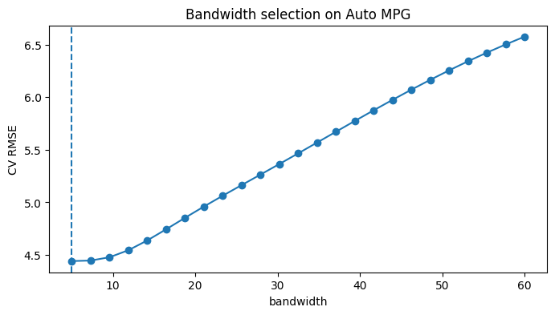

```python
# Manual CV over the training set.
# Use a modest grid because the estimator is O(n_train * n_eval).

hp_train_1d = X_train.ravel()

bandwidths = np.linspace(5, 60, 25)

kf = KFold(n_splits=5, shuffle=True, random_state=42)

cv_rmse = []

for h in bandwidths:
    fold_rmse = []

    for tr_idx, va_idx in kf.split(hp_train_1d):
        model = NadarayaWatsonRegressor(h).fit(
            hp_train_1d[tr_idx],
            y_train[tr_idx]
        )

        pred = model.predict(hp_train_1d[va_idx])
        fold_rmse.append(
            mean_squared_error(y_train[va_idx], pred) ** 0.5
        )

    cv_rmse.append(np.mean(fold_rmse))

best_h_real = bandwidths[np.argmin(cv_rmse)]

print("Best real-data bandwidth:", best_h_real)

plt.figure(figsize=(8, 4))
plt.plot(bandwidths, cv_rmse, marker="o")
plt.axvline(best_h_real, linestyle="--")
plt.xlabel("bandwidth")
plt.ylabel("CV RMSE")
plt.title("Bandwidth selection on Auto MPG")
plt.show()
```

```python
nw_real = NadarayaWatsonRegressor(best_h_real).fit(
    hp_train_1d,
    y_train
)

pred_nw = nw_real.predict(X_test.ravel())

metrics(y_test, pred_nw)
```

```
{'RMSE': 4.118738492740959,
 'MAE': 3.2240404598419126,
 'R2': 0.6636335531067247}
```

## 14.3 Regression Spline

We tune the number of knots by cross-validation.

```python
spline_pipe = Pipeline([
    ("spline", SplineTransformer(
        degree=3,
        include_bias=False
    )),
    ("ridge", Ridge())
])

param_grid = {
    "spline__n_knots": [4, 5, 6, 8, 10, 12],
    "ridge__alpha": [0.0, 0.01, 0.1, 1.0, 10.0]
}

search = GridSearchCV(
    spline_pipe,
    param_grid,
    scoring="neg_root_mean_squared_error",
    cv=5,
    n_jobs=-1
)

search.fit(X_train, y_train)

print("Best params:", search.best_params_)
print("Best CV RMSE:", -search.best_score_)

pred_spline_real = search.predict(X_test)

metrics(y_test, pred_spline_real)
```

```
Best params: {'ridge__alpha': 0.1, 'spline__n_knots': 8}
Best CV RMSE: 4.36296505969532
```

```
{'RMSE': 4.080686856435488,
 'MAE': 3.2353762927655074,
 'R2': 0.6698199956523616}
```

## 14.4 Gaussian Kernel Ridge Regression

Kernel ridge regression is not identical to Nadaraya–Watson smoothing, but it provides an important connection between:

- kernels,
- regularization,
- flexible nonlinear regression.

It solves a penalized objective in a reproducing-kernel Hilbert space.

```python
kr = Pipeline([
    ("scale", StandardScaler()),
    ("model", KernelRidge(kernel="rbf"))
])

kr_grid = {
    "model__alpha": [0.01, 0.1, 1.0, 10.0],
    "model__gamma": [0.01, 0.05, 0.1, 0.5, 1.0]
}

kr_search = GridSearchCV(
    kr,
    kr_grid,
    cv=5,
    scoring="neg_root_mean_squared_error",
    n_jobs=-1
)

kr_search.fit(X_train, y_train)

print("Best params:", kr_search.best_params_)

pred_kr = kr_search.predict(X_test)

metrics(y_test, pred_kr)
```

```
Best params: {'model__alpha': 0.1, 'model__gamma': 0.5}
```

```
{'RMSE': 4.038986044806033, 'MAE': 3.165415637776419, 'R2': 0.6765337782264624}
```

## 14.5 Visual Comparison of Fitted Curves

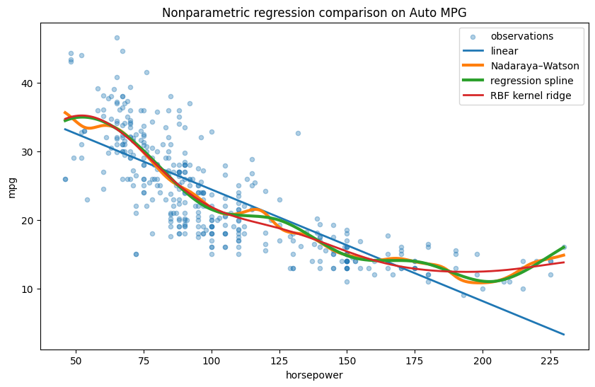

```python
hp_grid = np.linspace(
    auto["horsepower"].min(),
    auto["horsepower"].max(),
    400
).reshape(-1, 1)

plt.figure(figsize=(10, 6))

plt.scatter(
    auto["horsepower"],
    auto["mpg"],
    alpha=0.35,
    s=20,
    label="observations"
)

plt.plot(
    hp_grid,
    linear_hp.predict(hp_grid),
    linewidth=2,
    label="linear"
)

plt.plot(
    hp_grid,
    nw_real.predict(hp_grid.ravel()),
    linewidth=3,
    label="Nadaraya–Watson"
)

plt.plot(
    hp_grid,
    search.predict(hp_grid),
    linewidth=3,
    label="regression spline"
)

plt.plot(
    hp_grid,
    kr_search.predict(hp_grid),
    linewidth=2,
    label="RBF kernel ridge"
)

plt.xlabel("horsepower")
plt.ylabel("mpg")
plt.title("Nonparametric regression comparison on Auto MPG")
plt.legend()
plt.show()
```

## 14.6 Held-Out Test Comparison

```python
results = pd.DataFrame([
    {"Model": "Linear regression", **metrics(y_test, pred_linear)},
    {"Model": "Nadaraya-Watson", **metrics(y_test, pred_nw)},
    {"Model": "Regression spline", **metrics(y_test, pred_spline_real)},
    {"Model": "RBF kernel ridge", **metrics(y_test, pred_kr)},
])

results.sort_values("RMSE")
```

|  | Model | RMSE | MAE | R2 |
| --- | --- | --- | --- | --- |
| 3 | RBF kernel ridge | 4.038986 | 3.165416 | 0.676534 |
| 2 | Regression spline | 4.080687 | 3.235376 | 0.669820 |
| 1 | Nadaraya-Watson | 4.118738 | 3.224040 | 0.663634 |
| 0 | Linear regression | 4.680724 | 3.781268 | 0.565579 |

# 15. Multivariable Additive Case Study

A one-dimensional smoother is useful for interpretation, but fuel efficiency depends on several variables.

We now estimate a model of the form

# [ \text{mpg}

\beta_0 + f_1(\text{horsepower}) + f_2(\text{weight}) + f_3(\text{acceleration}) + f_4(\text{model year}) + \varepsilon. ]

Each (f_j) is represented with a spline basis.

This is a practical GAM-like additive model.

```python
features = [
    "horsepower",
    "weight",
    "acceleration",
    "model_year",
]

X_multi = auto[features].copy()
y_multi = auto["mpg"].to_numpy()

X_train_m, X_test_m, y_train_m, y_test_m = train_test_split(
    X_multi,
    y_multi,
    test_size=0.25,
    random_state=42
)

# Build one spline transformer per feature manually.
transformers = {}

def fit_additive_basis(df, n_knots=7):
    blocks = []

    for col in df.columns:
        tr = SplineTransformer(
            n_knots=n_knots,
            degree=3,
            include_bias=False
        )

        B = tr.fit_transform(df[[col]])
        transformers[col] = tr
        blocks.append(B)

    return np.column_stack(blocks)

B_train = fit_additive_basis(X_train_m)

def transform_additive_basis(df):
    blocks = []

    for col in df.columns:
        blocks.append(
            transformers[col].transform(df[[col]])
        )

    return np.column_stack(blocks)

B_test = transform_additive_basis(X_test_m)

additive_ridge = Ridge(alpha=1.0)
additive_ridge.fit(B_train, y_train_m)

pred_add_test = additive_ridge.predict(B_test)

metrics(y_test_m, pred_add_test)
```

```
{'RMSE': 2.4510430343248206,
 'MAE': 1.7551411101596635,
 'R2': 0.8808796108608193}
```

## 15.1 Tune the Additive Model Regularization

```python
alphas = np.logspace(-3, 3, 20)

best_alpha = None
best_score = np.inf

kf = KFold(n_splits=5, shuffle=True, random_state=42)

for alpha in alphas:
    fold_scores = []

    for tr_idx, va_idx in kf.split(B_train):
        model = Ridge(alpha=alpha)
        model.fit(B_train[tr_idx], y_train_m[tr_idx])

        pred = model.predict(B_train[va_idx])

        fold_scores.append(
            mean_squared_error(
                y_train_m[va_idx],
                pred
            ) ** 0.5
        )

    score = np.mean(fold_scores)

    if score < best_score:
        best_score = score
        best_alpha = alpha

print("Best alpha:", best_alpha)
print("CV RMSE:", best_score)

additive_ridge = Ridge(alpha=best_alpha).fit(
    B_train,
    y_train_m
)

pred_add_test = additive_ridge.predict(B_test)

metrics(y_test_m, pred_add_test)
```

```
Best alpha: 0.6951927961775606
CV RMSE: 2.9877575998829977
```

```
{'RMSE': 2.4514465845326403,
 'MAE': 1.7524712863643237,
 'R2': 0.8808403826510884}
```

# 16. Partial Effects from the Additive Model

Because the model is additive, we can inspect the estimated contribution of each variable separately.

The curves are centered for easier interpretation.

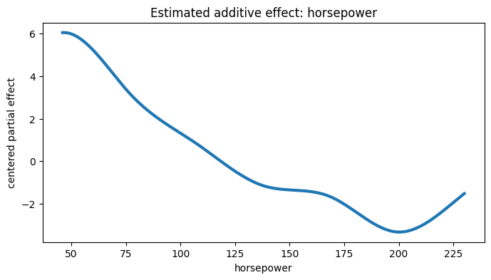

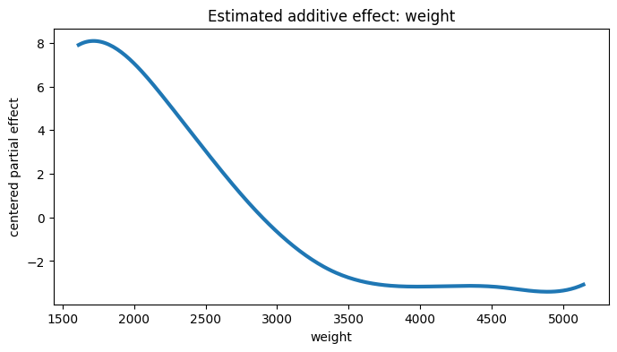

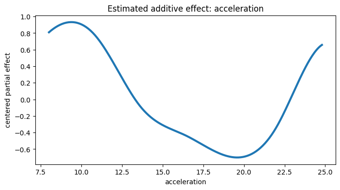

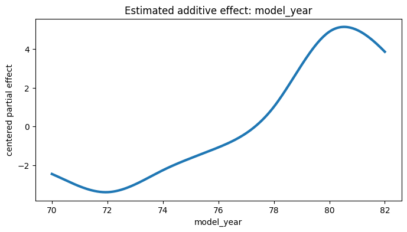

```python
offset = 0

for col in features:
    tr = transformers[col]
    n_basis = tr.n_features_out_

    coef = additive_ridge.coef_[offset:offset+n_basis]

    grid = np.linspace(
        X_train_m[col].min(),
        X_train_m[col].max(),
        250
    )

    Bgrid = tr.transform(
        pd.DataFrame({col: grid})
    )

    effect = Bgrid @ coef
    effect = effect - effect.mean()

    plt.figure(figsize=(8, 4))
    plt.plot(grid, effect, linewidth=3)
    plt.xlabel(col)
    plt.ylabel("centered partial effect")
    plt.title(f"Estimated additive effect: {col}")
    plt.show()

    offset += n_basis
```

# 17. Semiparametric Auto MPG Model

Suppose we believe:

- horsepower has a nonlinear effect,
- model year has an approximately linear trend.

Then we can fit

# [ \text{mpg}

\beta_0 + \beta_1\text{model year} + g(\text{horsepower}) + \varepsilon. ]

This gives the interpretability of a linear coefficient while preserving nonlinear flexibility for horsepower.

```python
semi_df = auto[["horsepower", "model_year", "mpg"]].copy()

X_train_s, X_test_s, y_train_s, y_test_s = train_test_split(
    semi_df[["horsepower", "model_year"]],
    semi_df["mpg"],
    test_size=0.25,
    random_state=42
)

hp_spline = SplineTransformer(
    n_knots=8,
    degree=3,
    include_bias=False
)

Bhp_train = hp_spline.fit_transform(
    X_train_s[["horsepower"]]
)

Bhp_test = hp_spline.transform(
    X_test_s[["horsepower"]]
)

Z_train = np.column_stack([
    X_train_s["model_year"].to_numpy(),
    Bhp_train
])

Z_test = np.column_stack([
    X_test_s["model_year"].to_numpy(),
    Bhp_test
])

semi_real = Ridge(alpha=0.1).fit(Z_train, y_train_s)

pred_semi_real = semi_real.predict(Z_test)

print("Estimated model-year linear coefficient:",
      semi_real.coef_[0])

metrics(y_test_s, pred_semi_real)
```

```
Estimated model-year linear coefficient: 0.6915438859666284
```

```
{'RMSE': 3.3903303244521332,
 'MAE': 2.672286742872789,
 'R2': 0.7720874402300539}
```

# 18. Bias–Variance Simulation

We now make the bias–variance trade-off visible empirically.

For a fixed evaluation point (x_0), repeatedly generate noisy datasets and estimate

[ \hat m_h(x_0). ]

Then estimate:

# [ \operatorname{Bias}^2

(E[\hat m_h(x_0)]-m(x_0))^2 ]

and

# [ \operatorname{Variance}

E[ (\hat m_h(x_0)-E[\hat m_h(x_0)])^2 ]. ]

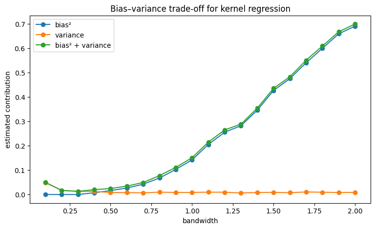

```python
def true_fun(x):
    return np.sin(x) + 0.15*x + 2

def bias_variance_experiment(
    bandwidth,
    n_rep=150,
    n_sample=120,
    x0=5.0
):
    estimates = []

    for _ in range(n_rep):
        xs = np.sort(
            np.random.uniform(0, 10, n_sample)
        )

        ys = true_fun(xs) + np.random.normal(
            0,
            0.4,
            n_sample
        )

        model = NadarayaWatsonRegressor(
            bandwidth
        ).fit(xs, ys)

        estimates.append(
            model.predict([x0])[0]
        )

    estimates = np.asarray(estimates)

    bias2 = (
        estimates.mean() - true_fun(x0)
    ) ** 2

    variance = estimates.var()

    return bias2, variance

hs = np.linspace(0.1, 2.0, 20)

bias2_values = []
var_values = []

for h in hs:
    b, v = bias_variance_experiment(h)
    bias2_values.append(b)
    var_values.append(v)

plt.figure(figsize=(9, 5))
plt.plot(hs, bias2_values, marker="o", label="bias²")
plt.plot(hs, var_values, marker="o", label="variance")
plt.plot(
    hs,
    np.array(bias2_values) + np.array(var_values),
    marker="o",
    label="bias² + variance"
)
plt.xlabel("bandwidth")
plt.ylabel("estimated contribution")
plt.title("Bias–variance trade-off for kernel regression")
plt.legend()
plt.show()
```

# 19. Computational Complexity

The naive Nadaraya–Watson prediction algorithm compares each query point against every training observation.

For:

- (n) training samples,
- (m) prediction locations,

the naive complexity is approximately

[ \Theta(mn). ]

Storage is

[ \Theta(n). ]

For very large datasets this can become expensive.

Possible accelerations include:

- binning,
- KD-trees / ball trees for compact-support kernels,
- approximate nearest neighbours,
- low-rank kernel approximations,
- random Fourier features,
- spline bases,
- subsampling,
- GPU vectorization.

Regression splines are often much faster at prediction time because, after fitting, evaluation depends mainly on the number of basis functions rather than all training observations.

# 20. Key Comparisons

| Method | Main Complexity Control | Strength | Limitation |
| --- | --- | --- | --- |
| Histogram | bin width | simple density estimate | discontinuous |
| KDE | bandwidth | smooth density | bandwidth sensitive |
| Nadaraya–Watson | bandwidth | intuitive local smoother | boundary bias; expensive |
| Local linear | bandwidth | better boundary behaviour | repeated weighted LS |
| Regression spline | knots / basis size | efficient and stable | knot/basis choice |
| Smoothing spline | smoothness penalty | elegant regularization | tuning required |
| Additive model | basis + penalties | handles several predictors | assumes additivity |
| Semiparametric model | parametric + smooth components | interpretability + flexibility | structure must be chosen |

A recurring theme is that almost every method solves the same statistical problem in a different way:

[ \boxed{ \text{Choose enough flexibility to capture signal, but not so much that noise is learned.} } ]

# 21. Exercises

### Exercise 1 — KDE

Replace the Gaussian kernel with:

- uniform,
- triangular,
- Epanechnikov.

Compare the estimates while keeping bandwidth fixed.

### Exercise 2 — Kernel Regression

Implement Epanechnikov-weighted Nadaraya–Watson regression.

### Exercise 3 — Local Polynomial

Compare polynomial degrees 0, 1, 2, and 3 using cross-validation.

### Exercise 4 — Splines

Tune:

- spline degree,
- number of knots,
- Ridge penalty.

### Exercise 5 — Auto MPG

Repeat the univariate analysis for:

- weight,
- displacement,
- acceleration.

### Exercise 6 — Additive Model

Add `cylinders` and `origin` to the additive model.

Think carefully about whether they should be:

- smooth numeric effects,
- categorical effects,
- parametric linear effects.

### Exercise 7 — Curse of Dimensionality

Simulate kernel regression in dimensions: [ d=1,2,4,8. ] Measure the sample size required to maintain similar test error.

### Exercise 8 — Model Selection

Compare:

- linear regression,
- spline regression,
- additive spline model,
- Random Forest,
- Gradient Boosting.

Then discuss the distinction between:

- predictive performance,
- interpretability,
- statistical smoothness,
- extrapolation.

# 22. Final Concept Map

The central ST5207-style progression can be remembered as:

[ \boxed{ \text{Histogram} \rightarrow \text{KDE} \rightarrow \text{Kernel Regression} \rightarrow \text{Local Polynomial} \rightarrow \text{Splines} \rightarrow \text{Additive Models} \rightarrow \text{Semiparametric Models} } ]

Underlying all of them are the same ideas:

[ \boxed{ \text{local information} + \text{smoothness} + \text{regularization} + \text{cross-validation} + \text{bias–variance trade-off} } ]

The important conceptual shift from ordinary regression is:

> Instead of choosing a fixed global equation first and estimating only its parameters, we estimate the shape of the regression function itself from the data.